# TS Final Project_Reg Model(with ARIMA errors)

Louise

3/9/2022

```r
library(readr)
urlfile="https://raw.githubusercontent.com/Beau-Smit/Time-Series/main/MN_Ag_YieldsAndInputs.csv"
dat <- read.csv(url(urlfile))
```

```r
#head(dat)
#tail(dat)
```

```r
# missing values
ag_df <- dat[!is.na(dat$Soy_BUperAcre),] %>% arrange(Year)
#ag_df
```

- 3 useful variable: Corn_BUperAcre, Wheat_BUperAcre, Soy_BUperAcre, yearly data from 1934 to 2021
- each crop have 4 fertilizers, but too many nulls and gaps in those features ➔ will be ignored

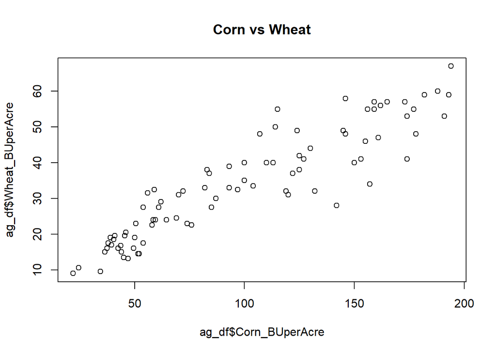

```r
# plot for relationship between variables
plot(ag_df$Corn_BUperAcre, ag_df$Wheat_BUperAcre, main = "Corn vs Wheat")
```

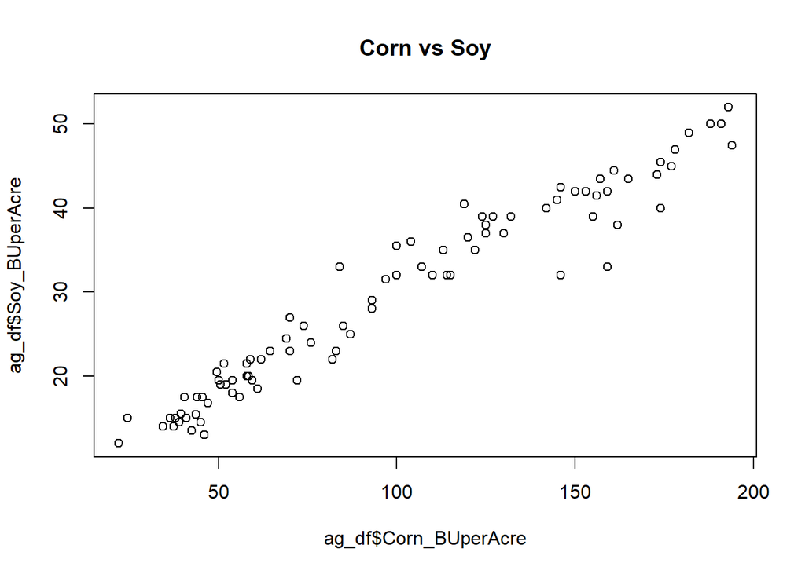

```r
plot(ag_df$Corn_BUperAcre, ag_df$Soy_BUperAcre, main = "Corn vs Soy")
```

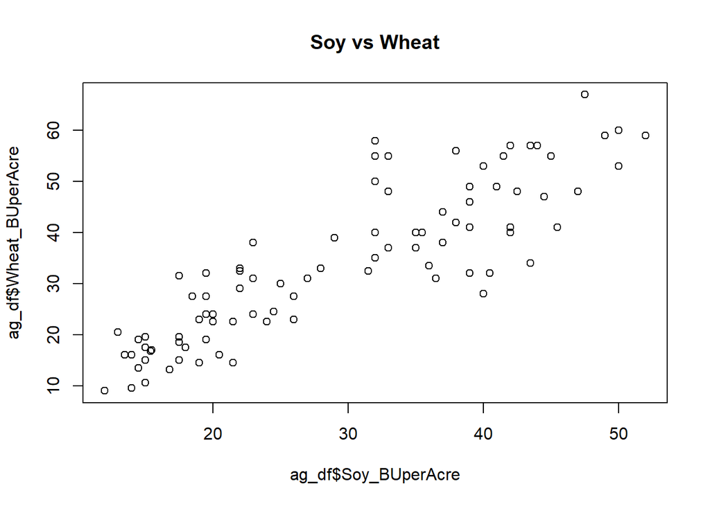

```r
plot(ag_df$Soy_BUperAcre, ag_df$Wheat_BUperAcre, main = "Soy vs Wheat")
```

linear relationship

```r
# ts object
corn <- ts(ag_df$Corn_BUperAcre, frequency = 1, start = 1934)
wheat <- ts(ag_df$Wheat_BUperAcre, frequency = 1, start = 1934)
soy <- ts(ag_df$Soy_BUperAcre, frequency = 1, start = 1934)
```

```r
# corr
df <- cbind(corn, soy, wheat)
cor(df)
```

```
##            corn       soy     wheat
## corn  1.0000000 0.9702692 0.9132233
## soy   0.9702692 1.0000000 0.8684502
## wheat 0.9132233 0.8684502 1.0000000
```

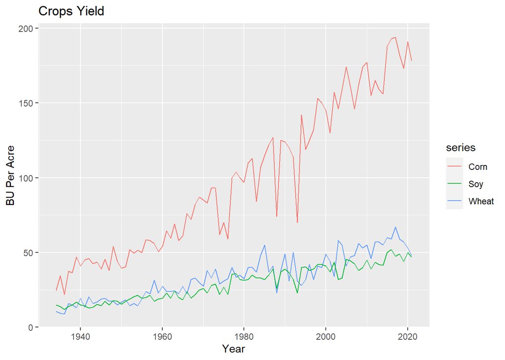

```r
# plot ts
autoplot(corn, main = "Crops Yield", xlab = "Year", ylab = "BU Per Acre", series = "Corn") +
  autolayer(wheat, series = "Wheat") +
  autolayer(soy, series = "Soy")
```

- boxcox needed
- potential seasonality or just trend? need to check

```r
# lambda calculation
BoxCox.lambda(corn)
```

```
## [1] 0.4744898
```

```r
BoxCox.lambda(soy)
```

```
## [1] -0.7589477
```

```r
BoxCox.lambda(wheat)
```

```
## [1] 0.08641062
```

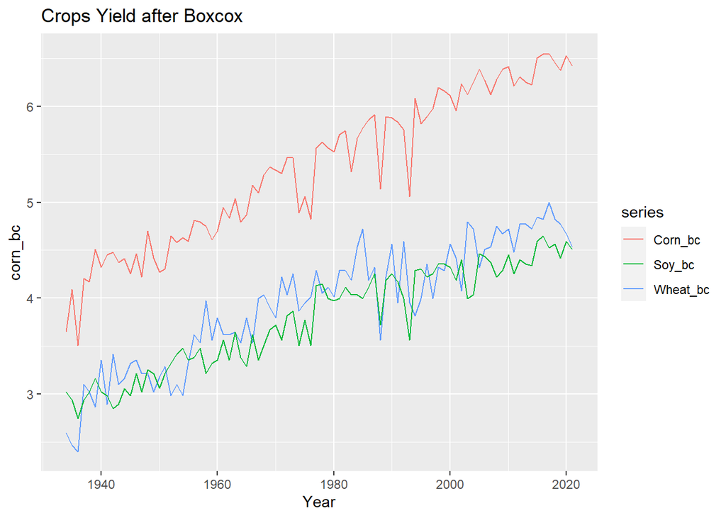

```r
# test with different lambda and plot ts to determine lambda for all three variables
corn_bc <- BoxCox(corn, lambda = 0.08)
soy_bc <- BoxCox(soy, lambda = 0.08)
wheat_bc <- BoxCox(wheat, lambda = 0.08)

autoplot(corn_bc, main = "Crops Yield after Boxcox", xlab = "Year", series = "Corn_bc") +
  autolayer(wheat_bc, series = "Wheat_bc") +
  autolayer(soy_bc, series = "Soy_bc")
```

can proceed with lambda = 0.5 (square root trans plus linear trans) or lambda = 0 (log trans) for easier interpretation

```r
# create variables for later use
corn_sqrt <- BoxCox(corn, lambda = 0.5)
soy_sqrt <- BoxCox(soy, lambda = 0.5)
wheat_sqrt <- BoxCox(wheat, lambda = 0.5)

corn_log <- BoxCox(corn, lambda = 0)
soy_log <- BoxCox(soy, lambda = 0)
wheat_log <- BoxCox(wheat, lambda = 0)

df_sqrt <- cbind(corn_sqrt, soy_sqrt, wheat_sqrt)
df_log <- cbind(corn_log, soy_log, wheat_log)

cor(df_sqrt) # check corr after boxcox
```

```
##            corn_sqrt  soy_sqrt wheat_sqrt
## corn_sqrt  1.0000000 0.9728512  0.9222551
## soy_sqrt   0.9728512 1.0000000  0.8801989
## wheat_sqrt 0.9222551 0.8801989  1.0000000
```

```r
cor(df_log)
```

```
##            corn_log   soy_log wheat_log
## corn_log  1.0000000 0.9708346 0.9278778
## soy_log   0.9708346 1.0000000 0.8835926
## wheat_log 0.9278778 0.8835926 1.0000000
```

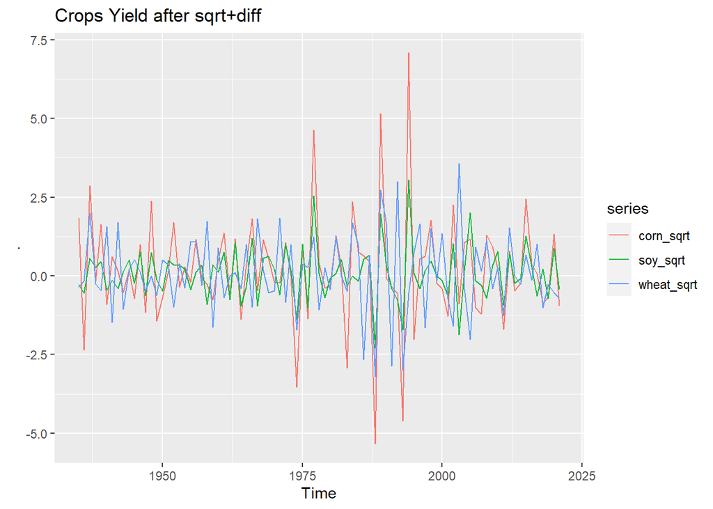

```r
# differencing and stationary check: determine d and D

diff(df_sqrt) %>% autoplot(main = "Crops Yield after sqrt+diff")
```

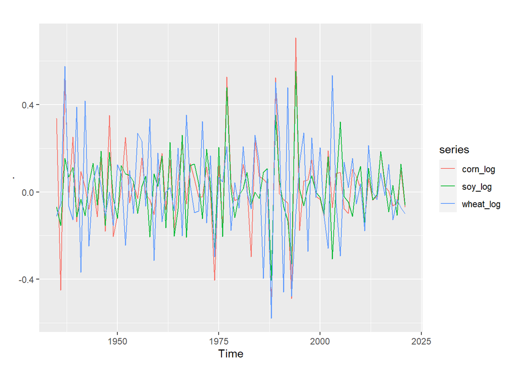

```r
diff(df_log) %>% autoplot(maing = "Crops Yield after log+diff")
```

```r
adf.test(diff(df_log)[,1])
```

```
##
##  Augmented Dickey-Fuller Test
##
## data:  diff(df_log)[, 1]
## Dickey-Fuller = -5.57, Lag order = 4, p-value = 0.01
## alternative hypothesis: stationary
```

```r
adf.test(diff(df_sqrt)[,1])
```

```
##
##  Augmented Dickey-Fuller Test
##
## data:  diff(df_sqrt)[, 1]
## Dickey-Fuller = -5.498, Lag order = 4, p-value = 0.01
## alternative hypothesis: stationary
```

both sqrt+1st differencing and log+1st differencing can bring to stationary ts, but log trans+1st differencing had relative constant variance. - proceed with log + d=1 (no seasonal differencing)

```r
# train/test split
split <- ts_split(df, sample.out = 8)

train <- split$train
test <- split$test

head(train)
```

```
## Time Series:
## Start = 1934
## End = 1939
## Frequency = 1
##      corn  soy wheat
## 1934 24.6 15.0  10.6
## 1935 34.5 14.0   9.5
## 1936 22.0 12.0   9.0
## 1937 37.5 14.0  16.0
## 1938 36.5 15.0  15.0
## 1939 47.0 16.8  13.2
```

#### Regression

```r
# regression
tslm_corn_log <- tslm(formula = corn ~ soy + wheat,
                      data = train,lambda = 0, biasadj = TRUE)
tslm_wheat_log <- tslm(formula = wheat ~ corn + soy,
                       data = train,lambda = 0, biasadj = TRUE)
tslm_soy_log <- tslm(formula = soy ~ corn + wheat,
                     data = train, lambda = 0, biasadj = TRUE)
```

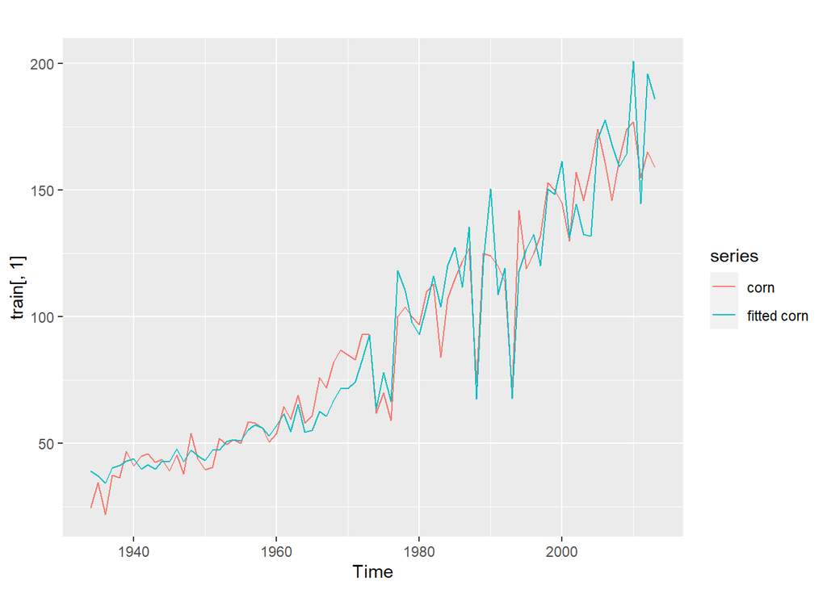

```r
# plot regression fitted values & actual values in training set
autoplot(train[,1], series = "corn") +
  autolayer(tslm_corn_log$fitted.values, series = "fitted corn")
```

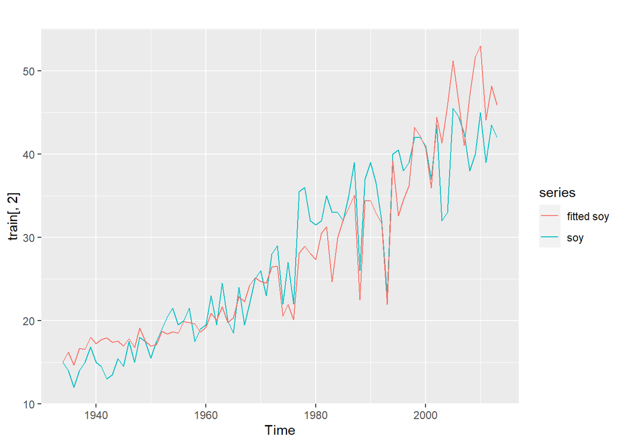

```r
autoplot(train[,2], series = "soy") +
  autolayer(tslm_soy_log$fitted.values, series = "fitted soy")
```

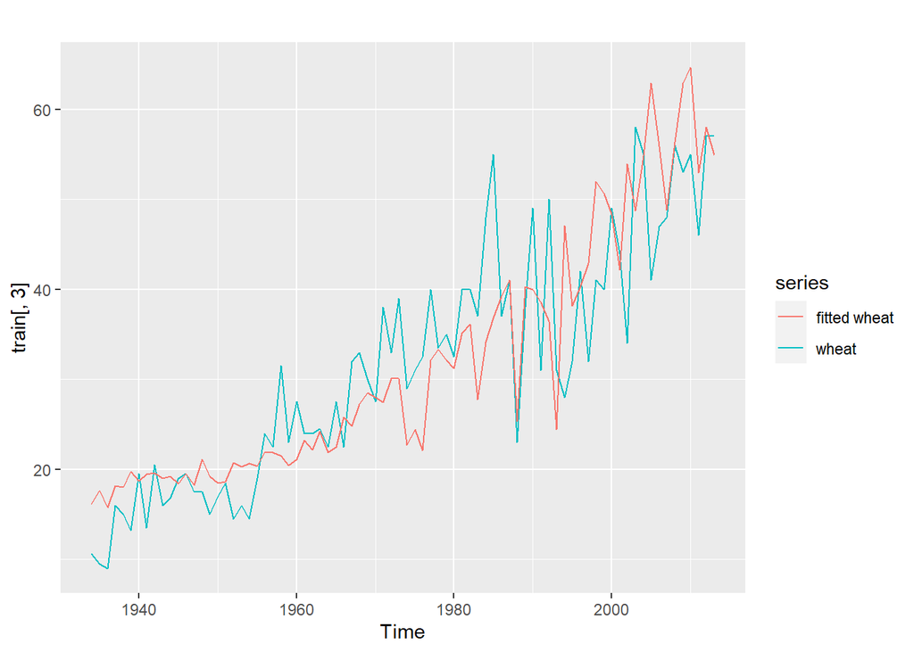

```r
autoplot(train[,3], series = "wheat") +
  autolayer(tslm_wheat_log$fitted.values, series = "fitted wheat")
```

```r
#summary(tslm_corn_log)
```

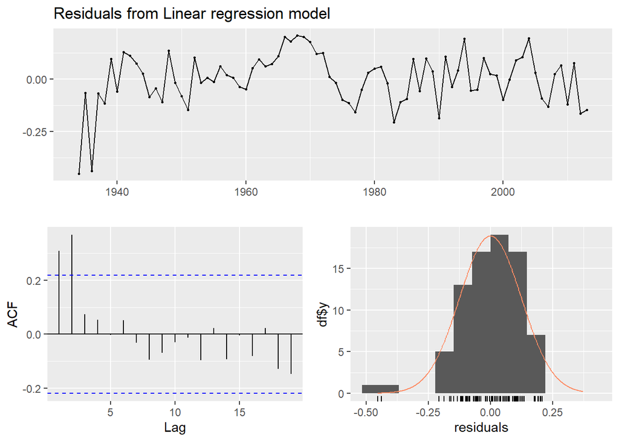

```
##
##  Breusch-Godfrey test for serial correlation of order up to 10
##
## data:  Residuals from Linear regression model
## LM test = 18.727, df = 10, p-value = 0.04387
```

```r
checkresiduals(tslm_corn_log)
```

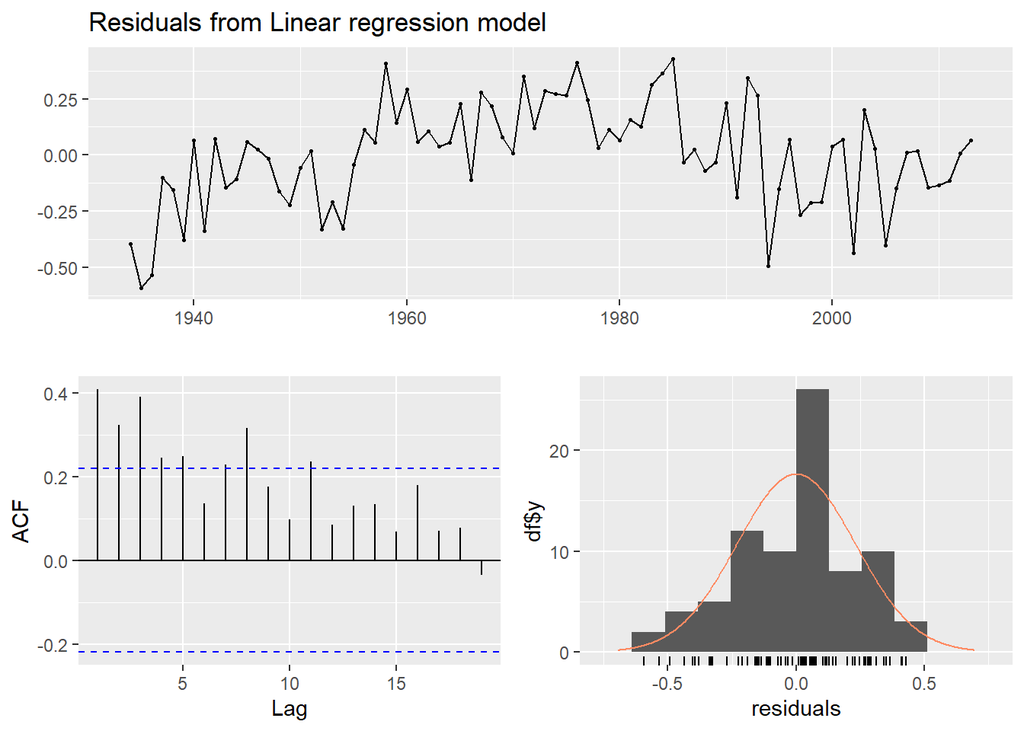

```
##
##  Breusch-Godfrey test for serial correlation of order up to 10
##
## data:  Residuals from Linear regression model
## LM test = 27.651, df = 10, p-value = 0.002052
```

```r
checkresiduals(tslm_wheat_log)
```

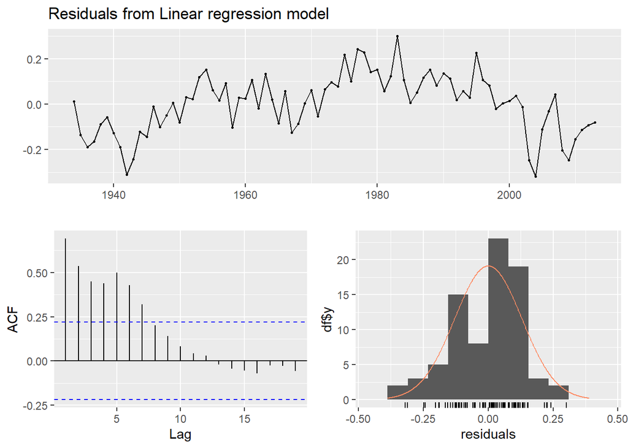

```
##
##  Breusch-Godfrey test for serial correlation of order up to 10
##
## data:  Residuals from Linear regression model
## LM test = 47.309, df = 10, p-value = 8.296e-07
```

```r
checkresiduals(tslm_soy_log)
```

Breusch-Godfrey test for all three regression models had a low p-value, indicating residuals were autocorrelated ➔use regression with ARIMA error model is appropriate

#### Reg model with ARIMA errors

```r
# model estimation
regARIMA_corn_log <- auto.arima(train[,1], xreg = train[,2:3], d = 1,
                                 lambda = 0, biasadj = TRUE,
                                trace = TRUE, ic = "aicc")
```

```
##
##  Regression with ARIMA(2,1,2) errors : Inf
##  Regression with ARIMA(0,1,0) errors : -93.79451
##  Regression with ARIMA(1,1,0) errors : -115.0797
##  Regression with ARIMA(0,1,1) errors : -113.3263
##  ARIMA(0,1,0)                    : -95.67449
##  Regression with ARIMA(2,1,0) errors : -112.739
##  Regression with ARIMA(1,1,1) errors : -112.7578
##  Regression with ARIMA(2,1,1) errors : -110.8127
##  ARIMA(1,1,0)                    : -116.6853
##  ARIMA(2,1,0)                    : -114.4267
##  ARIMA(1,1,1)                    : -114.5018
##  ARIMA(0,1,1)                    : -114.2481
##  ARIMA(2,1,1)                    : -112.6257
##
##  Best model: Regression with ARIMA(1,1,0) errors
```

```r
regARIMA_wheat_log <- auto.arima(train[,3], xreg = train[,1:2], d = 1,
                                  lambda = 0, biasadj = TRUE,
                                 trace = TRUE, ic = "aicc")
```

```
##
##  Regression with ARIMA(2,1,2) errors : -35.84565
##  Regression with ARIMA(0,1,0) errors : -10.81825
##  Regression with ARIMA(1,1,0) errors : -31.70577
##  Regression with ARIMA(0,1,1) errors : -42.45002
##  ARIMA(0,1,0)                    : -12.70607
##  Regression with ARIMA(1,1,1) errors : -40.2021
##  Regression with ARIMA(0,1,2) errors : -40.19192
##  Regression with ARIMA(1,1,2) errors : -37.80064
##  ARIMA(0,1,1)                    : -40.30095
##
##  Best model: Regression with ARIMA(0,1,1) errors
```

```r
regARIMA_soy_log <- auto.arima(train[,2], xreg = train[,c(1,3)], d = 1,
                                lambda = 0, biasadj = TRUE,
                               trace = TRUE, ic = "aicc")
```

```
##
##  Regression with ARIMA(2,1,2) errors : -148.4947
##  Regression with ARIMA(0,1,0) errors : -143.8384
##  Regression with ARIMA(1,1,0) errors : -146.95
##  Regression with ARIMA(0,1,1) errors : -152.3029
##  ARIMA(0,1,0)                    : -146.0293
##  Regression with ARIMA(1,1,1) errors : -153.0306
##  Regression with ARIMA(2,1,1) errors : -151.0528
##  Regression with ARIMA(1,1,2) errors : -150.8289
##  Regression with ARIMA(0,1,2) errors : -153.1617
##  Regression with ARIMA(0,1,3) errors : -150.9538
##  Regression with ARIMA(1,1,3) errors : -148.475
##  ARIMA(0,1,2)                    : -154.8839
##  ARIMA(0,1,1)                    : -154.0022
##  ARIMA(1,1,2)                    : -152.6093
##  ARIMA(0,1,3)                    : -152.7257
##  ARIMA(1,1,1)                    : -154.7165
##  ARIMA(1,1,3)                    : -150.3168
##
##  Best model: Regression with ARIMA(0,1,2) errors
```

```r
summary(regARIMA_corn_log)
```

```
## Series: train[, 1]
## Regression with ARIMA(1,1,0) errors
## Box Cox transformation: lambda= 0
##
## Coefficients:
##           ar1     soy   wheat
##       -0.5405  0.0307  0.0086
## s.e.   0.1022  0.0028  0.0018
##
## sigma^2 = 0.01242:  log likelihood = 62.61
## AIC=-117.23   AICc=-116.69   BIC=-107.75
##
## Training set error measures:
##                     ME     RMSE      MAE         MPE    MAPE      MASE     ACF1
## Training set -0.207898 10.87483 8.070486 -0.04132217 8.74346 0.7054308 0.101712
```

```r
summary(regARIMA_soy_log)
```

```
## Series: train[, 2]
## Regression with ARIMA(0,1,2) errors
## Box Cox transformation: lambda= 0
##
## Coefficients:
##           ma1      ma2   corn    wheat
##       -0.4119  -0.1832  8e-03  -0.0048
## s.e.   0.1115   0.1044  7e-04   0.0015
##
## sigma^2 = 0.007536:  log likelihood = 82.85
## AIC=-155.71   AICc=-154.88   BIC=-143.86
##
## Training set error measures:
##                      ME     RMSE     MAE        MPE     MAPE      MASE
## Training set 0.01122101 2.471502 1.91766 -0.2101431 6.894274 0.5751525
##                    ACF1
## Training set 0.05077889
```

```r
summary(regARIMA_wheat_log)
```

```
## Series: train[, 3]
## Regression with ARIMA(0,1,1) errors
## Box Cox transformation: lambda= 0
##
## Coefficients:
##           ma1   drift    corn      soy
##       -0.7176  0.0144  0.0086  -0.0245
## s.e.   0.0820  0.0062  0.0021   0.0076
##
## sigma^2 = 0.03114:  log likelihood = 26.64
## AIC=-43.27   AICc=-42.45   BIC=-31.42
##
## Training set error measures:
##                      ME     RMSE      MAE       MPE     MAPE      MASE
## Training set -0.5001007 5.543729 4.150116 -2.919392 13.88209 0.7062886
##                     ACF1
## Training set -0.07300869
```

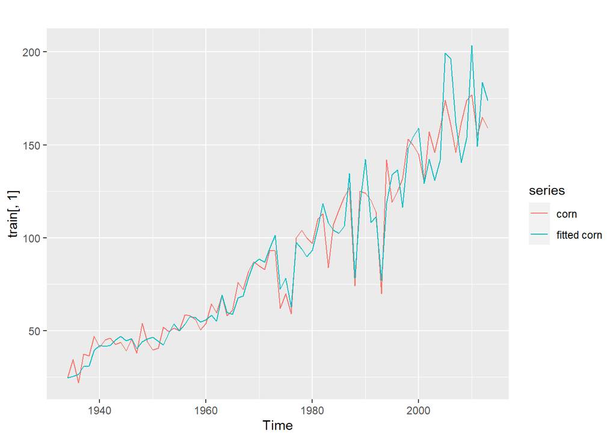

```r
# plot fitted values based on regression with ARIMA errors model vs actual values in training set
autoplot(train[,1], series = "corn") +
  autolayer(regARIMA_corn_log$fitted, series = "fitted corn")
```

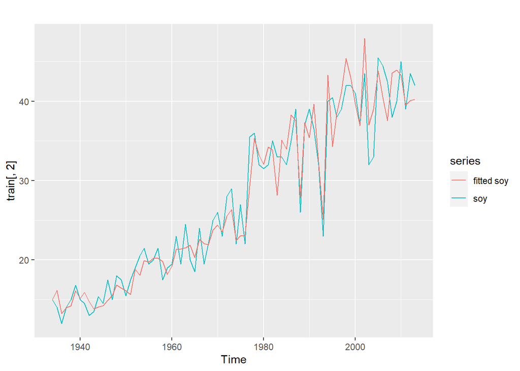

```r
autoplot(train[,2], series = "soy") +
  autolayer(regARIMA_soy_log$fitted, series = "fitted soy")
```

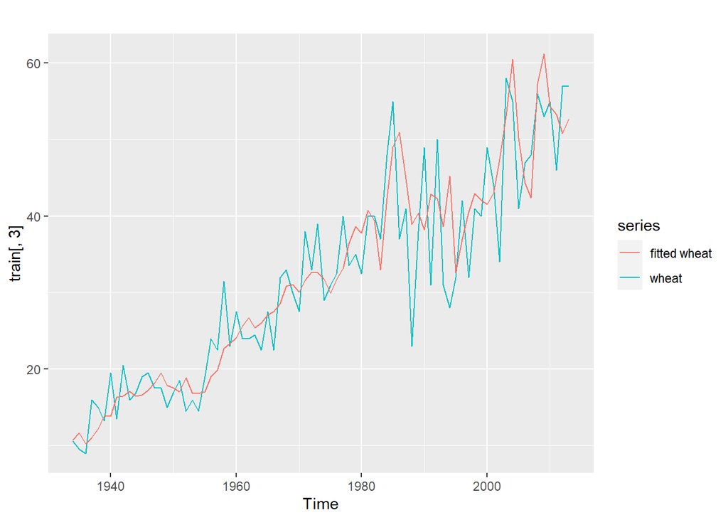

```r
autoplot(train[,3], series = "wheat") +
  autolayer(regARIMA_wheat_log$fitted, series = "fitted wheat")
```

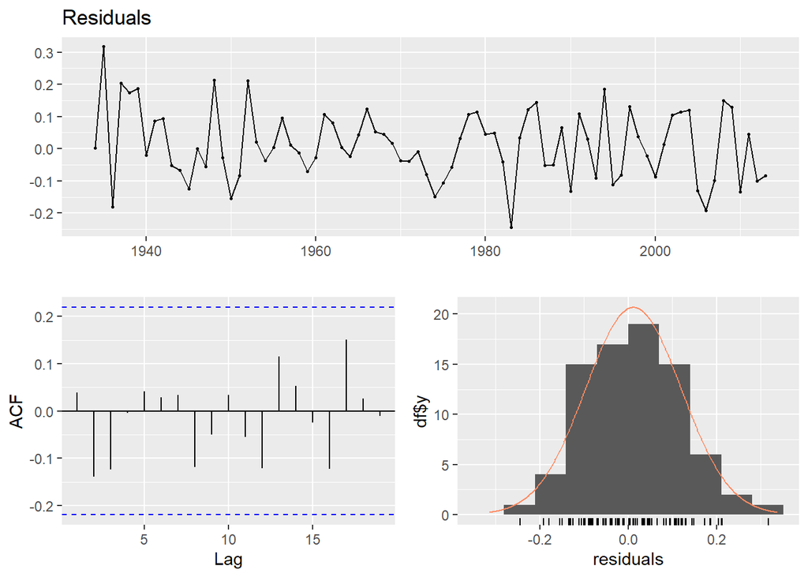

```r
# residauls(), checkresiduals(), zero mean, (const variance)
# autocorr test
# normality test

checkresiduals(regARIMA_corn_log$residuals)
```

```r
Box.test(regARIMA_corn_log$residuals, type =  "Ljung-Box")
```

```
##
##  Box-Ljung test
##
## data:  regARIMA_corn_log$residuals
## X-squared = 0.12427, df = 1, p-value = 0.7245
```

```r
shapiro.test(regARIMA_corn_log$residuals)
```

```
##
##  Shapiro-Wilk normality test
##
## data:  regARIMA_corn_log$residuals
## W = 0.99196, p-value = 0.9037
```

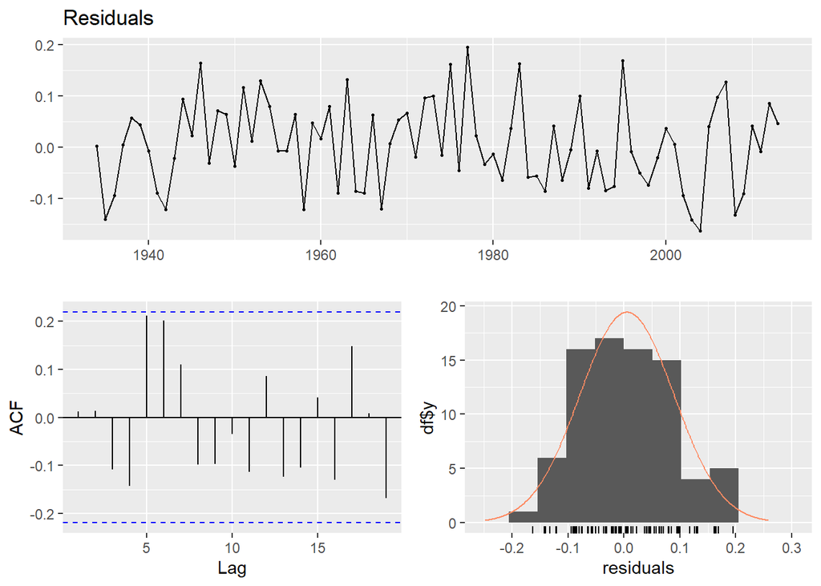

```r
checkresiduals(regARIMA_soy_log$residuals)
```

```r
Box.test(regARIMA_soy_log$residuals, type =  "Ljung-Box")
```

```
##
##  Box-Ljung test
##
## data:  regARIMA_soy_log$residuals
## X-squared = 0.01404, df = 1, p-value = 0.9057
```

```r
shapiro.test(regARIMA_soy_log$residuals)
```

```
##
##  Shapiro-Wilk normality test
##
## data:  regARIMA_soy_log$residuals
## W = 0.98308, p-value = 0.3716
```

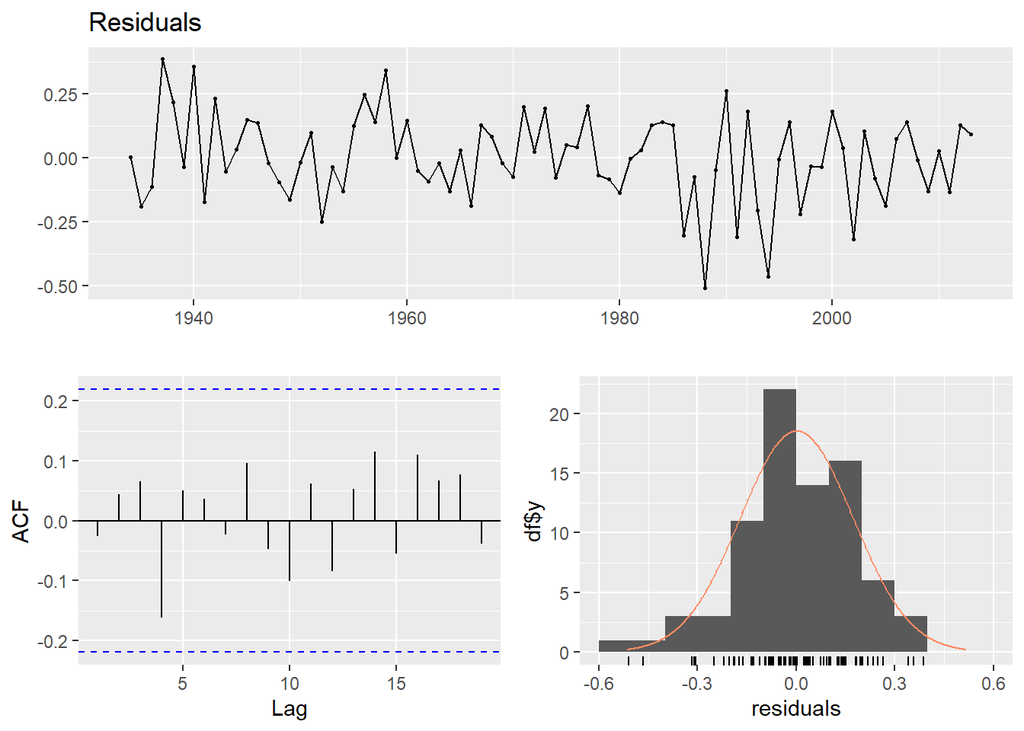

```r
checkresiduals(regARIMA_wheat_log$residuals)
```

```r
Box.test(regARIMA_wheat_log$residuals, type =  "Ljung-Box")
```

```
##
##  Box-Ljung test
##
## data:  regARIMA_wheat_log$residuals
## X-squared = 0.054311, df = 1, p-value = 0.8157
```

```r
shapiro.test(regARIMA_wheat_log$residuals)
```

```
##
##  Shapiro-Wilk normality test
##
## data:  regARIMA_wheat_log$residuals
## W = 0.98429, p-value = 0.4341
```

Ljung-Box test had large p-value(> 0.05) for all three models, showing these model had captured patterns in the series so that there were no autocorrelation in the residuals

Shapiro-Wilk test had large p-value(>0.05) for all three models as well, indicating the residuals are normally distributed

```r
# forecast
head(test)
```

```
## Time Series:
## Start = 2014
## End = 2019
## Frequency = 1
##      corn  soy wheat
## 2014  156 41.5    55
## 2015  188 50.0    60
## 2016  193 52.0    59
## 2017  194 47.5    67
## 2018  182 49.0    59
## 2019  173 44.0    57
```

```r
forecast_corn <- forecast(regARIMA_corn_log, h = 8, level = 95, xreg = test[,2:3])
forecast_soy <- forecast(regARIMA_soy_log, h = 8, level = 95, xreg = test[,c(1,3)])
forecast_wheat <- forecast(regARIMA_wheat_log, h = 8, level = 95, xreg = test[,1:2])
```

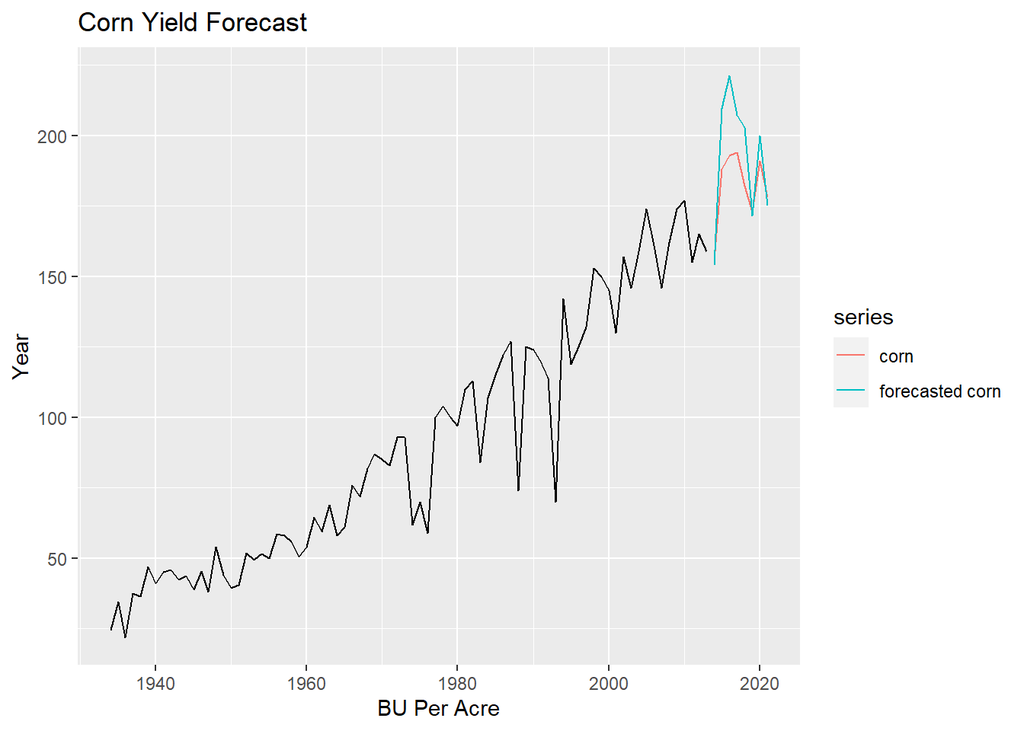

```r
# forecast values from the model vs actual values test setting
autoplot(train[,1], main = "Corn Yield Forecast", xlab = "BU Per Acre", ylab = "Year") + autolayer(test[,1], series = "corn") +
  autolayer(forecast_corn$mean, series = "forecasted corn")
```

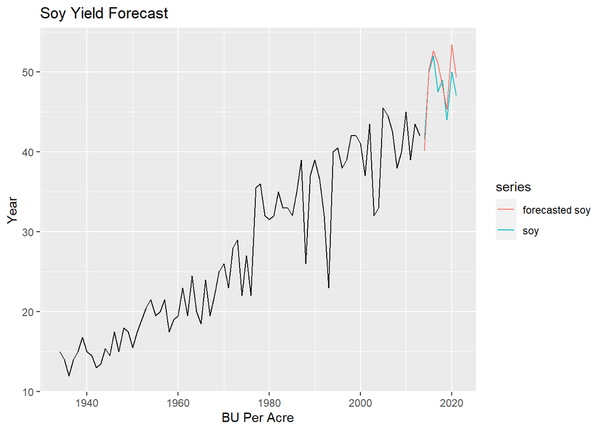

```r
autoplot(train[,2], main = "Soy Yield Forecast", xlab = "BU Per Acre", ylab = "Year") + autolayer(test[,2], series = "soy") +
  autolayer(forecast_soy$mean, series = "forecasted soy")
```

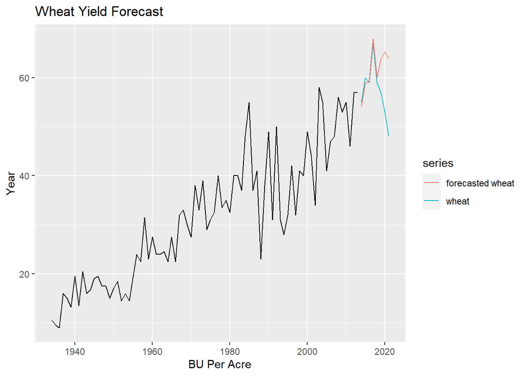

```r
autoplot(train[,3], main = "Wheat Yield Forecast", xlab = "BU Per Acre", ylab = "Year") + autolayer(test[,3], series = "wheat") + autolayer(forecast_wheat$mean, series = "forecasted wheat")
```

```r
# model evaluation (testing set)
accuracy(forecast_corn, test[,1])
```

```
##                      ME     RMSE       MAE         MPE     MAPE      MASE
## Training set  -0.207898 10.87483  8.070486 -0.04132217 8.743460 0.7054308
## Test set     -10.882898 15.74107 12.395036 -5.70577445 6.597732 1.0834342
##                   ACF1 Theil's U
## Training set 0.1017120        NA
## Test set     0.0397616 0.9749435
```

```r
accuracy(forecast_soy, test[,2])
```

```
##                       ME     RMSE      MAE        MPE     MAPE      MASE
## Training set  0.01122101 2.471502 1.917660 -0.2101431 6.894274 0.5751525
## Test set     -1.19677573 2.097111 1.727209 -2.4437551 3.653112 0.5180317
##                     ACF1 Theil's U
## Training set  0.05077889        NA
## Test set     -0.02747642 0.4120829
```

```r
accuracy(forecast_wheat, test[,3])
```

```
##                      ME     RMSE      MAE       MPE      MAPE      MASE
## Training set -0.5001007 5.543729 4.150116 -2.919392 13.882087 0.7062886
## Test set     -4.3933817 7.500202 4.894424 -8.525913  9.392116 0.8329588
##                     ACF1 Theil's U
## Training set -0.07300869        NA
## Test set      0.60016618  1.630694
```

#### from baseline_models.Rmd but with testing set obs = 8

```r
# split train and test sets
first_test_yr <- 2014

corn_train <- window(corn, end=first_test_yr-1)
corn_test <- window(corn, start=first_test_yr)
wheat_train <- window(wheat, end=first_test_yr-1)
wheat_test <- window(wheat, start=first_test_yr)
soy_train <- window(soy, end=first_test_yr-1)
soy_test <- window(soy, start=first_test_yr)

h <- 8

# holt method
#plot(holt(corn_train, h=h, damped=T))
#plot(holt(wheat_train, h=h, damped=T, exponential=T))
#plot(holt(soy_train, h=h, damped=T))

# actual estimates
holt_predictions_corn <- holt(corn_train, h=h, damped=T)$mean
holt_predictions_soy <- holt(soy_train, h=h, damped=T, exponential=T)$mean
holt_predictions_wheat <- holt(wheat_train, h=h, damped=T)$mean

# auto.arima
lam_corn <- BoxCox.lambda(corn_train)
lam_soy <- BoxCox.lambda(soy_train)
lam_wheat <- BoxCox.lambda(wheat_train)

arima_mdl_corn <- auto.arima(corn_train, lambda = lam_corn)
arima_mdl_soy <- auto.arima(soy_train, lambda = lam_soy)
arima_mdl_wheat <- auto.arima(wheat_train, lambda = lam_wheat)

arima_predictions_corn <- (forecast(arima_mdl_corn, h=h))$mean
arima_predictions_soy <- (forecast(arima_mdl_soy, h=h))$mean
arima_predictions_wheat <- (forecast(arima_mdl_wheat, h=h))$mean

#plot(forecast(arima_mdl_corn, h=h))
#plot(forecast(arima_mdl_soy, h=h))
#plot(forecast(arima_mdl_wheat, h=h))
```

#### corn forecast accuracy

```r
accuracy(forecast_corn, test[,1])
```

```
##                      ME     RMSE       MAE         MPE     MAPE      MASE
## Training set  -0.207898 10.87483  8.070486 -0.04132217 8.743460 0.7054308
## Test set     -10.882898 15.74107 12.395036 -5.70577445 6.597732 1.0834342
##                   ACF1 Theil's U
## Training set 0.1017120        NA
## Test set     0.0397616 0.9749435
```

```r
accuracy(holt_predictions_corn, test[,1])
```

```
##                ME     RMSE      MAE        MPE     MAPE       ACF1 Theil's U
## Test set 0.944604 11.84905 10.57804 0.09916779 5.910176 0.02921006 0.6168138
```

```r
accuracy(arima_predictions_corn, test[,1])
```

```
##                 ME     RMSE      MAE        MPE     MAPE     ACF1 Theil's U
## Test set -0.645953 13.69239 11.94713 -0.8306112 6.726573 0.123104 0.6921467
```

#### soy forecast accuracy

```r
accuracy(forecast_soy, test[,2])
```

```
##                       ME     RMSE      MAE        MPE     MAPE      MASE
## Training set  0.01122101 2.471502 1.917660 -0.2101431 6.894274 0.5751525
## Test set     -1.19677573 2.097111 1.727209 -2.4437551 3.653112 0.5180317
##                     ACF1 Theil's U
## Training set  0.05077889        NA
## Test set     -0.02747642 0.4120829
```

```r
accuracy(holt_predictions_soy, test[,2])
```

```
##                ME    RMSE      MAE      MPE     MAPE       ACF1 Theil's U
## Test set 4.146507 5.23593 4.428616 8.280166 8.959948 -0.2000273  1.093498
```

```r
accuracy(arima_predictions_soy, test[,2])
```

```
##                 ME     RMSE      MAE       MPE     MAPE      ACF1 Theil's U
## Test set -4.716829 6.761101 5.799576 -10.34482 12.46396 0.3936672   1.30302
```

#### wheat forecast accuracy

```r
accuracy(forecast_wheat, test[,3])
```

```
##                      ME     RMSE      MAE       MPE      MAPE      MASE
## Training set -0.5001007 5.543729 4.150116 -2.919392 13.882087 0.7062886
## Test set     -4.3933817 7.500202 4.894424 -8.525913  9.392116 0.8329588
##                     ACF1 Theil's U
## Training set -0.07300869        NA
## Test set      0.60016618  1.630694
```

```r
accuracy(holt_predictions_wheat, test[,3])
```

```
##                ME     RMSE      MAE      MPE    MAPE     ACF1 Theil's U
## Test set 2.696357 6.069359 4.997021 3.868084 8.56216 0.362208  1.251973
```

```r
accuracy(arima_predictions_wheat, test[,3])
```

```
##                 ME    RMSE      MAE       MPE     MAPE      ACF1 Theil's U
## Test set -4.164681 8.28203 6.159755 -8.448626 11.50054 0.4846803  1.793495
```